# Project: Investigating a Baseball Dataset

Introduction Data Wrangling Exploratory Data Analysis Conclusions

## Introduction¶

A baseball game is played between two teams, each composed of nine players, that take turns playing offense (batting and baserunning) and defense (pitching and fielding). The goal of the game is to score more points (runs) than the other team. Pandas and Numpy will be the tools to use in conducting the analysis.

This investigation will explore the following questions

1. Which were the 3 best teams in the 2rd millenium era(2001-todate)
2. Which skill contributes most to winning, My hypothesis - Pitching contributes more to a winning strategy than the batting average?

```python
# importing all the tools necessary for this exercise
import pandas as pd
import numpy as np
import matplotlib.pyplot as plt
import seaborn as sns
% matplotlib inline
```

## Data Wrangling

This process will involve loading the data, cleaning it by identifying the errors and correcting them, identifying missing values, correcting the gap so as to improve later analysis This procedure will involve triming, subseting, sorting and combining datasets to prepare them for later analysis. ***Make sure that you document your steps carefully and justify your cleaning decisions.

```python
# loading Main files - master, batting, fielding and pitching
Master_df = pd.read_csv('Master.csv')
batting_df = pd.read_csv('Batting.csv')
fielding_df = pd.read_csv('Fielding.csv')
pitching_df = pd.read_csv('Pitching.csv')
teams_df = pd.read_csv('Teams.csv')
```

## Understanding structure of the data

Data inspection will use the head, tail, shape, info, describe and value_counts method

```python
# Explore the main 3 data sets with the head  and tail function
# Missing values are shown as NaN
# dataframe structures are different with playerID as the common factor
print('master')
print(Master_df.head(2))
print
print('batting')
print(batting_df.head(2))
print
print('Pitching')
print(pitching_df.head(2))
print
print('Teams')
print(teams_df.head(2))
```

```
master
    playerID  birthYear  birthMonth  birthDay birthCountry birthState  \
0  aardsda01     1981.0        12.0      27.0          USA         CO
1  aaronha01     1934.0         2.0       5.0          USA         AL

  birthCity  deathYear  deathMonth  deathDay    ...     nameLast    nameGiven  \
0    Denver        NaN         NaN       NaN    ...      Aardsma  David Allan
1    Mobile        NaN         NaN       NaN    ...        Aaron  Henry Louis

  weight height bats throws       debut   finalGame   retroID    bbrefID
0  215.0   75.0    R      R  2004-04-06  2015-08-23  aardd001  aardsda01
1  180.0   72.0    R      R  1954-04-13  1976-10-03  aaroh101  aaronha01

[2 rows x 24 columns]

batting
    playerID  yearID  stint teamID lgID   G   AB   R   H  2B  ...    RBI   SB  \
0  abercda01    1871      1    TRO  NaN   1    4   0   0   0  ...    0.0  0.0
1   addybo01    1871      1    RC1  NaN  25  118  30  32   6  ...   13.0  8.0

    CS  BB   SO  IBB  HBP  SH  SF  GIDP
0  0.0   0  0.0  NaN  NaN NaN NaN   NaN
1  1.0   4  0.0  NaN  NaN NaN NaN   NaN

[2 rows x 22 columns]

Pitching
    playerID  yearID  stint teamID lgID   W   L   G  GS  CG  ...   IBB  WP  \
0  bechtge01    1871      1    PH1  NaN   1   2   3   3   2  ...   NaN NaN
1  brainas01    1871      1    WS3  NaN  12  15  30  30  30  ...   NaN NaN

   HBP  BK  BFP  GF    R  SH  SF  GIDP
0  NaN   0  NaN NaN   42 NaN NaN   NaN
1  NaN   0  NaN NaN  292 NaN NaN   NaN

[2 rows x 30 columns]

Teams
   yearID lgID teamID franchID divID  Rank   G  Ghome   W   L     ...       \
0    1871  NaN    BS1      BNA   NaN     3  31    NaN  20  10     ...
1    1871  NaN    CH1      CNA   NaN     2  28    NaN  19   9     ...

   DP     FP                     name                     park  attendance  \
0 NaN  0.838     Boston Red Stockings      South End Grounds I         NaN
1 NaN  0.829  Chicago White Stockings  Union Base-Ball Grounds         NaN

   BPF  PPF  teamIDBR  teamIDlahman45  teamIDretro
0  103   98       BOS             BS1          BS1
1  104  102       CHI             CH1          CH1

[2 rows x 48 columns]
```

```python
# Identifiy missing values - using batting data
batting_df.isnull().sum()
batting_df.isnull().sum().sample(3)
```

```
HR       0
RBI    424
H        0
dtype: int64
```

```python
# Explore main data sets with the shape function
# shows the rows and columns in each of the dataframes
print('master')
print(Master_df.shape)
print
print('batting')
print(batting_df.shape)
print
print('Pitching')
print(pitching_df.shape)
print
print('Teams')
print(teams_df.shape)
print
```

```
master
(19105, 24)

batting
(102816, 22)

Pitching
(44963, 30)

Teams
(2835, 48)
```

```python
print('Master')
print(Master_df.columns)
print
```

```
Master
Index([u'playerID', u'birthYear', u'birthMonth', u'birthDay', u'birthCountry',
       u'birthState', u'birthCity', u'deathYear', u'deathMonth', u'deathDay',
       u'deathCountry', u'deathState', u'deathCity', u'nameFirst', u'nameLast',
       u'nameGiven', u'weight', u'height', u'bats', u'throws', u'debut',
       u'finalGame', u'retroID', u'bbrefID'],
      dtype='object')
```

```python
# Explore main data sets with the .info function
# shows the index,data types and memory of the data
print('master')
Master_df.info()
print
# batting_df.info()
print
# pitching_df.info()
print
```

```
master
<class 'pandas.core.frame.DataFrame'>
RangeIndex: 19105 entries, 0 to 19104
Data columns (total 24 columns):
playerID        19105 non-null object
birthYear       18973 non-null float64
birthMonth      18803 non-null float64
birthDay        18656 non-null float64
birthCountry    19036 non-null object
birthState      18534 non-null object
birthCity       18925 non-null object
deathYear       9441 non-null float64
deathMonth      9440 non-null float64
deathDay        9439 non-null float64
deathCountry    9436 non-null object
deathState      9390 non-null object
deathCity       9431 non-null object
nameFirst       19068 non-null object
nameLast        19105 non-null object
nameGiven       19068 non-null object
weight          18251 non-null float64
height          18320 non-null float64
bats            17920 non-null object
throws          18126 non-null object
debut           18910 non-null object
finalGame       18910 non-null object
retroID         19049 non-null object
bbrefID         19103 non-null object
dtypes: float64(8), object(16)
memory usage: 3.5+ MB
```

```python
# Explore summary stats of the main data sets with the .describe function
# the output gives the numeric statistics of the variables ie the mean weight of the players is 186 . Mean the min and
# max weight is 65 and 320 ibs respectively.
print('master')
print(Master_df.describe())
print
# print(batting_df.describe())
# print(pitching_df.describe())
```

```
master
          birthYear    birthMonth      birthDay    deathYear   deathMonth  \
count  18973.000000  18803.000000  18656.000000  9441.000000  9440.000000
mean    1931.435356      6.629474     15.614816  1964.287364     6.483581
std       41.555514      3.468103      8.750216    31.808030     3.529655
min     1820.000000      1.000000      1.000000  1872.000000     1.000000
25%     1895.000000      4.000000      8.000000  1942.000000     3.000000
50%     1937.000000      7.000000     16.000000  1967.000000     6.000000
75%     1969.000000     10.000000     23.000000  1990.000000    10.000000
max     1996.000000     12.000000     31.000000  2017.000000    12.000000

          deathDay        weight        height
count  9439.000000  18251.000000  18320.000000
mean     15.569552    186.375596     72.273799
std       8.779552     21.524765      2.603904
min       1.000000     65.000000     43.000000
25%       8.000000    170.000000     71.000000
50%      15.000000    185.000000     72.000000
75%      23.000000    200.000000     74.000000
max      31.000000    320.000000     83.000000
```

```python
# calculate summary stats  of the categorical variables - bats and throws
# shows that the unique values are Right hand R, Lefthand L or both.  The counts for each are also shown.
count_bats = (Master_df['bats'].value_counts(dropna = False))
print(count_bats)
print
count_throws = (Master_df['throws'].value_counts(dropna = False))
print(count_throws)
```

```
R      11788
L       4957
NaN     1185
B       1175
Name: bats, dtype: int64

R      14472
L       3653
NaN      979
S          1
Name: throws, dtype: int64
```

```
[]
```

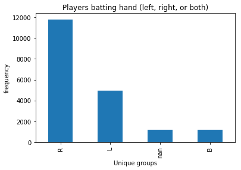

```python
%matplotlib inline
# plot a histogram of the count_bats variable above
count_bats.plot(kind = 'bar', x = 'bats', y ='frequency')
# specify axis
plt.xlabel('Unique groups')
plt.ylabel('frequency')
plt.title('Players batting hand (left, right, or both)')
plt.plot()
# shows almost three times more right handed players compared to lefties - expected.  It also shows that 6.6%
# play with both hands -thats surprising
```

### Data challenges identified

1. missing data
2. separate data files
3. outliers

### Tidying data for analysis

# 1. variable must be a separate column and each row is a separate observation - this was not an issue

# 2. process may involve splitting columns or reshaping the dataset to make later analyis easier.

## Combining data for analysis

```python
# the datasets came in different files
# combining batting and pitching
pitbat_df = pitching_df.merge(batting_df, on=['playerID','yearID', 'teamID','lgID'],how ='inner')
pitbat_df.sample(5)
```

|  | playerID | yearID | stint_x | teamID | lgID | W | L | G_x | GS | CG | ... | RBI | SB | CS | BB_y | SO_y | IBB_y | HBP_y | SH_y | SF_y | GIDP_y |
| --- | --- | --- | --- | --- | --- | --- | --- | --- | --- | --- | --- | --- | --- | --- | --- | --- | --- | --- | --- | --- | --- |
| 855 | fulmech02 | 1886 | 1 | BL2 | AA | 0 | 0 | 1 | 0 | 0 | ... | 30.0 | 29.0 | NaN | 48 | NaN | NaN | 2.0 | NaN | NaN | NaN |
| 41384 | fistedo01 | 2012 | 1 | DET | AL | 10 | 10 | 26 | 26 | 2 | ... | 0.0 | 0.0 | 0.0 | 0 | 1.0 | 0.0 | 0.0 | 0.0 | 0.0 | 0.0 |
| 11209 | galehde01 | 1941 | 1 | SLA | AL | 9 | 10 | 30 | 24 | 11 | ... | 5.0 | 0.0 | 0.0 | 2 | 14.0 | NaN | 0.0 | 5.0 | NaN | 5.0 |
| 31116 | bohanbr01 | 1997 | 1 | NYN | NL | 6 | 4 | 19 | 14 | 0 | ... | 4.0 | 0.0 | 0.0 | 0 | 15.0 | 0.0 | 0.0 | 1.0 | 1.0 | 0.0 |
| 14762 | meyerja01 | 1955 | 1 | PHI | NL | 6 | 11 | 50 | 5 | 0 | ... | 1.0 | 0.0 | 0.0 | 4 | 7.0 | 0.0 | 0.0 | 1.0 | 0.0 | 2.0 |

5 rows × 48 columns

```python
# investigating the merged data
# pitbat_df.info()
```

```python
# Cleaning the data by removing duplicates
# no duplicates found
pitbat_df.drop_duplicates().shape
```

```
(44995, 48)
```

```python
# are there nulls?
nan=pitbat_df.isnull().sum()
```

```python
# dropped all columns with missing values to reduce on the high dimensionality before analysis
# dropped because its not clear why they are milling
nonapitbat_df=pitbat_df.dropna(axis=1)
nonapitbat_df.isnull().sum().head()
```

```
playerID    0
yearID      0
stint_x     0
teamID      0
W           0
dtype: int64
```

```python
# nonapitbat_df.info()
# checking to ensure that dtypes are right
```

```python
# Subset the Masters Data File and clean it
submaster_df = Master_df[['playerID','weight','height','bats','throws']]
submaster_df.isnull().sum()
```

```
playerID       0
weight       854
height       785
bats        1185
throws       979
dtype: int64
```

```python
# Cleaning sub_master_df
# Removing null values in weight and height Variables by filling it with the mean of the column
# Without a good understanding of why bats and throws values are mixing, Nan is replaced with 0
# filling the missing values in the weight, height, bats and throws columns
submaster_df = Master_df[['playerID','weight','height','bats','throws']]
A= submaster_df['weight'].mean()
B= submaster_df['height'].mean()
full_weight = submaster_df['weight'].fillna(A)
full_height = submaster_df['height'].fillna(B)
full_bats = submaster_df['bats'].fillna(0)
full_throws = submaster_df['throws'].fillna(0)
```

```python
submaster_df.isnull().sum()
```

```
playerID       0
weight       854
height       785
bats        1185
throws       979
dtype: int64
```

```python
# merge submaster data with nonapitbat_df
print(nonapitbat_df.head(3))
print
submaster_df.head(3)
```

```
    playerID  yearID  stint_x teamID   W   L  G_x  GS  CG  SHO  ...   R_x  \
0  bechtge01    1871        1    PH1   1   2    3   3   2    0  ...    42
1  brainas01    1871        1    WS3  12  15   30  30  30    0  ...   292
2  fergubo01    1871        1    NY2   0   0    1   0   0    0  ...     9

   stint_y  G_y   AB  R_y  H_y  2B  3B  HR_y  BB_y
0        1   20   94   24   33   9   1     1     2
1        1   30  134   24   30   4   0     0     7
2        1   33  158   30   38   6   1     0     3

[3 rows x 28 columns]
```

|  | playerID | weight | height | bats | throws |
| --- | --- | --- | --- | --- | --- |
| 0 | aardsda01 | 215.0 | 75.0 | R | R |
| 1 | aaronha01 | 180.0 | 72.0 | R | R |
| 2 | aaronto01 | 190.0 | 75.0 | R | R |

```python
# merged 2 data frames on playerID and checked that they have no missing values
masterpitbat_df= nonapitbat_df.merge(submaster_df, on=['playerID'], how='inner')
p=masterpitbat_df.isnull().sum()
```

```python
#for duplicates and NaN values
nodupmasterpitbat_df=masterpitbat_df.drop_duplicates()
na=nodupmasterpitbat_df.isnull().sum()
```

```python
print(nodupmasterpitbat_df.sample(5))
```

```
        playerID  yearID  stint_x teamID   W   L  G_x  GS  CG  SHO   ...    \
18280  normafr01    1972        1    SDN   9  11   42  28  10    6   ...
17802  duffaji01    1961        1    SFN   5   1   24   4   1    0   ...
27724  cluttbr01    1986        1    ML4   0   1   20   0   0    0   ...
22463  tananfr01    1993        2    NYA   0   2    3   3   0    0   ...
20162  niekrjo01    1982        1    HOU  17  12   35  35  16    5   ...

       R_y  H_y  2B  3B  HR_y  BB_y  weight  height  bats  throws
18280    5    8   1   0     0     8   155.0    68.0     B       L
17802    2    5   2   0     1     1   175.0    73.0     R       R
27724    0    0   0   0     0     0   223.0    76.0     R       R
22463    0    0   0   0     0     0   180.0    74.0     L       L
20162    2    8   2   0     0     1   185.0    73.0     R       R

[5 rows x 32 columns]
```

```python
# filling in the missing values for weight and height
A= nodupmasterpitbat_df['weight'].mean()
B= nodupmasterpitbat_df['height'].mean()
full_weight = nodupmasterpitbat_df['weight'].fillna(A)
full_height = nodupmasterpitbat_df['height'].fillna(B)
full_bats = nodupmasterpitbat_df['bats'].fillna(0)
full_throws = nodupmasterpitbat_df['throws'].fillna(0)
```

```python
# updating the data frame
nodupmasterpitbat_df['weight'] = full_weight
nodupmasterpitbat_df['height'] = full_height
nodupmasterpitbat_df['bats'] = full_bats
nodupmasterpitbat_df['throws'] = full_throws
```

```python
# confirmation that all missing values have been removed
nodupmasterpitbat_df.info()
```

```
<class 'pandas.core.frame.DataFrame'>
Int64Index: 44995 entries, 0 to 44994
Data columns (total 32 columns):
playerID    44995 non-null object
yearID      44995 non-null int64
stint_x     44995 non-null int64
teamID      44995 non-null object
W           44995 non-null int64
L           44995 non-null int64
G_x         44995 non-null int64
GS          44995 non-null int64
CG          44995 non-null int64
SHO         44995 non-null int64
SV          44995 non-null int64
IPouts      44995 non-null int64
H_x         44995 non-null int64
ER          44995 non-null int64
HR_x        44995 non-null int64
BB_x        44995 non-null int64
SO_x        44995 non-null int64
BK          44995 non-null int64
R_x         44995 non-null int64
stint_y     44995 non-null int64
G_y         44995 non-null int64
AB          44995 non-null int64
R_y         44995 non-null int64
H_y         44995 non-null int64
2B          44995 non-null int64
3B          44995 non-null int64
HR_y        44995 non-null int64
BB_y        44995 non-null int64
weight      44995 non-null float64
height      44995 non-null float64
bats        44995 non-null object
throws      44995 non-null object
dtypes: float64(2), int64(26), object(4)
memory usage: 11.3+ MB
```

```python
teams_df.sample(2)
```

|  | yearID | lgID | teamID | franchID | divID | Rank | G | Ghome | W | L | ... | DP | FP | name | park | attendance | BPF | PPF | teamIDBR | teamIDlahman45 | teamIDretro |
| --- | --- | --- | --- | --- | --- | --- | --- | --- | --- | --- | --- | --- | --- | --- | --- | --- | --- | --- | --- | --- | --- |
| 855 | 1929 | NL | NY1 | SFG | NaN | 3 | 152 | 77.0 | 84 | 67 | ... | 163.0 | 0.975 | New York Giants | Polo Grounds IV | 868806.0 | 100 | 97 | NYG | NY1 | NY1 |
| 169 | 1885 | NL | PRO | PRO | NaN | 4 | 110 | NaN | 53 | 57 | ... | NaN | 0.903 | Providence Grays | Messer Street Grounds | NaN | 97 | 95 | PRO | PRO | PRO |

2 rows × 48 columns

```python
subteam_df= teams_df[['yearID','teamID', 'Rank', 'name']]
#Testing that data is clean and code is running smoothly
# 0 missing data confirmed
assert(subteam_df > 0).all().all()
```

```python
#Testing that data is clean and code is running smoothly
assert(nonapitbat_df >= 0).all().all()
```

```python
#Testing that data is clean and code is running smoothly
assert(nodupmasterpitbat_df >= 0).all().all()
# 0 missing data confirmed
```

```python
# saving the main data to a new csv file
nodupmasterpitbat_df.to_csv('sub_baseball.csv')
```

### data sets processed and ready for the next stage of analysis

1. subteam_df
2. nodupmasterpitbat_df
3. nonapitbat_df

## Exploratory Data Analysis¶

```python
# Getting summary stats of the data
nodupmasterpitbat_df.describe()
```

|  | yearID | stint_x | W | L | G_x | GS | CG | SHO | SV | IPouts | ... | G_y | AB | R_y | H_y | 2B | 3B | HR_y | BB_y | weight | height |
| --- | --- | --- | --- | --- | --- | --- | --- | --- | --- | --- | --- | --- | --- | --- | --- | --- | --- | --- | --- | --- | --- |
| count | 44995.000000 | 44995.000000 | 44995.000000 | 44995.000000 | 44995.000000 | 44995.000000 | 44995.000000 | 44995.000000 | 44995.000000 | 44995.000000 | ... | 44995.000000 | 44995.000000 | 44995.000000 | 44995.000000 | 44995.000000 | 44995.000000 | 44995.000000 | 44995.000000 | 44995.000000 | 44995.00000 |
| mean | 1968.663318 | 1.080364 | 4.713502 | 4.713924 | 23.673097 | 9.481031 | 3.149794 | 0.448339 | 1.504167 | 253.765841 | ... | 25.800556 | 26.377020 | 2.557084 | 5.181465 | 0.734593 | 0.195066 | 0.155906 | 1.478542 | 192.763268 | 73.40521 |
| std | 37.574677 | 0.287437 | 5.812183 | 4.988117 | 18.491519 | 12.281404 | 7.079961 | 1.109435 | 4.989997 | 257.285227 | ... | 21.037660 | 55.643248 | 8.572132 | 14.524004 | 2.447613 | 0.978986 | 1.009526 | 4.829304 | 21.544631 | 2.41437 |
| min | 1871.000000 | 1.000000 | 0.000000 | 0.000000 | 1.000000 | 0.000000 | 0.000000 | 0.000000 | 0.000000 | 0.000000 | ... | 1.000000 | 0.000000 | 0.000000 | 0.000000 | 0.000000 | 0.000000 | 0.000000 | 0.000000 | 120.000000 | 63.00000 |
| 25% | 1941.000000 | 1.000000 | 0.000000 | 1.000000 | 7.000000 | 0.000000 | 0.000000 | 0.000000 | 0.000000 | 49.000000 | ... | 8.000000 | 0.000000 | 0.000000 | 0.000000 | 0.000000 | 0.000000 | 0.000000 | 0.000000 | 180.000000 | 72.00000 |
| 50% | 1978.000000 | 1.000000 | 2.000000 | 3.000000 | 21.000000 | 3.000000 | 0.000000 | 0.000000 | 0.000000 | 167.000000 | ... | 23.000000 | 4.000000 | 0.000000 | 0.000000 | 0.000000 | 0.000000 | 0.000000 | 0.000000 | 190.000000 | 73.40521 |
| 75% | 2001.000000 | 1.000000 | 7.000000 | 8.000000 | 35.000000 | 17.000000 | 3.000000 | 0.000000 | 1.000000 | 392.000000 | ... | 37.000000 | 33.000000 | 2.000000 | 5.000000 | 0.000000 | 0.000000 | 0.000000 | 1.000000 | 205.000000 | 75.00000 |
| max | 2016.000000 | 4.000000 | 59.000000 | 48.000000 | 106.000000 | 75.000000 | 75.000000 | 16.000000 | 62.000000 | 2040.000000 | ... | 158.000000 | 658.000000 | 177.000000 | 257.000000 | 49.000000 | 25.000000 | 59.000000 | 150.000000 | 300.000000 | 83.00000 |

8 rows × 28 columns

The stats show that there extremely large differences in the min and max values for IPout nodupmasterpitbat_df, AB, H and weight. Implying high variability and maybe the need of the log scale

```python
# Pandas Pearson correlation  coefficient
nodupmasterpitbat_df.corr().sample(2)
# note the W correlations
```

|  | yearID | stint_x | W | L | G_x | GS | CG | SHO | SV | IPouts | ... | G_y | AB | R_y | H_y | 2B | 3B | HR_y | BB_y | weight | height |
| --- | --- | --- | --- | --- | --- | --- | --- | --- | --- | --- | --- | --- | --- | --- | --- | --- | --- | --- | --- | --- | --- |
| SHO | -0.257114 | -0.062530 | 0.693593 | 0.517180 | 0.229425 | 0.637135 | 0.682286 | 1.000000 | -0.056616 | 0.672797 | ... | 0.194194 | 0.352328 | 0.187183 | 0.246632 | 0.192577 | 0.127053 | 0.076774 | 0.185662 | -0.114312 | -0.098296 |
| R_x | -0.283613 | -0.111483 | 0.809922 | 0.903844 | 0.451408 | 0.887764 | 0.775794 | 0.505302 | -0.042301 | 0.925592 | ... | 0.373280 | 0.437367 | 0.261817 | 0.315459 | 0.238356 | 0.180896 | 0.076642 | 0.227309 | -0.113729 | -0.118800 |

2 rows × 28 columns

## Data Visualisation

### Visualising sample data using a Scatter plot

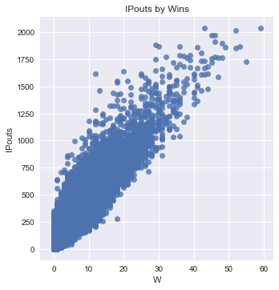

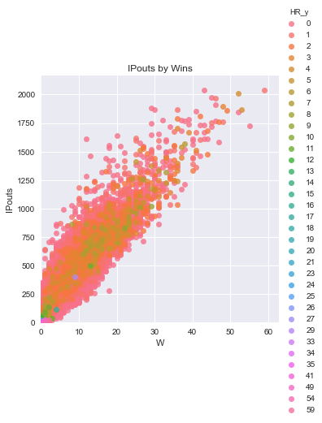

```python
df=nodupmasterpitbat_df[['W','IPouts','R_y','AB','HR_y']]
# add 'fit_reg=False' means No regression line
# hue argument allows addition of a 3rd dimension 'HR' to the plot
# plot using seaborn
sns.set()

sns.lmplot(x='W', y='IPouts', data = df, fit_reg=False)
# Set title with matplotlib
plt.title('IPouts by Wins')

print
sns.lmplot(x='W', y='IPouts', data = df, fit_reg=False,hue='HR_y')

# Set title with matplotlib
plt.title('IPouts by Wins')

# Tweak using Matplotlib
plt.ylim(0, None)
plt.xlim(0, None)

plt.show()
```

```python
nodupmasterpitbat_df.sample()
```

|  | playerID | yearID | stint_x | teamID | W | L | G_x | GS | CG | SHO | ... | R_y | H_y | 2B | 3B | HR_y | BB_y | weight | height | bats | throws |
| --- | --- | --- | --- | --- | --- | --- | --- | --- | --- | --- | --- | --- | --- | --- | --- | --- | --- | --- | --- | --- | --- |
| 21171 | dunegji01 | 1970 | 1 | CHN | 0 | 2 | 7 | 0 | 0 | 0 | ... | 0 | 1 | 1 | 0 | 0 | 0 | 205.0 | 73.0 | R | R |

1 rows × 32 columns

there is a clear relationship between IPouts and Wins W. weight and height are not linearly related with winning. While Saves SV, homeruns HR and walks BB have a inverse relationship. Variables R, at bats AB and especially Outs pitched IPouts have a linear relationship meaning these variables contribute directly to winning.

```python
df = nodupmasterpitbat_df[['W', 'throws', 'bats']]
df.sample()
```

|  | W | throws | bats |
| --- | --- | --- | --- |
| 29394 | 12 | R | R |

```
[]
```

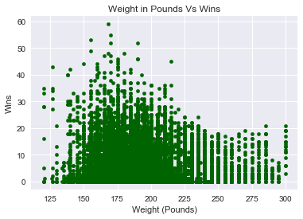

```python
#plot a scatterplot of Weight vs W with Pandas
df=nodupmasterpitbat_df[['W','IPouts','R_y','AB','HR_y', 'weight']]
% matplotlib inline
sns.set()
nodupmasterpitbat_df.plot(kind='scatter', x='weight', y='W',c = 'darkgreen')

plt.xlabel('Weight (Pounds)')
plt.ylabel('Wins')
plt.title('Weight in Pounds Vs Wins')
plt.plot()
# the trend is a normal distribution
# shows that excess weight is not favorable for wins
```

```
[]
```

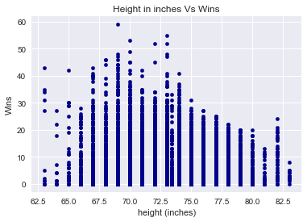

```python
#plot a scatterplot of Weight vs W with Pandas
df=nodupmasterpitbat_df[['W','IPouts','R_y','AB','HR_y', 'weight','height']]
% matplotlib inline
sns.set()
nodupmasterpitbat_df.plot(kind='scatter', x='height', y='W', c ='darkblue')

plt.xlabel('height (inches)')
plt.ylabel('Wins')
plt.title('Height in inches Vs Wins')
plt.plot()
# the trend is a normal distribution
# shows that excess weight is not favorable for wins
```

```python
# The plots show that its only players whose weight is less than 225 pounds who were able to make above 30 Wins.  And
# its only players with 75 inches and below that were able to make above 30 wins.
```

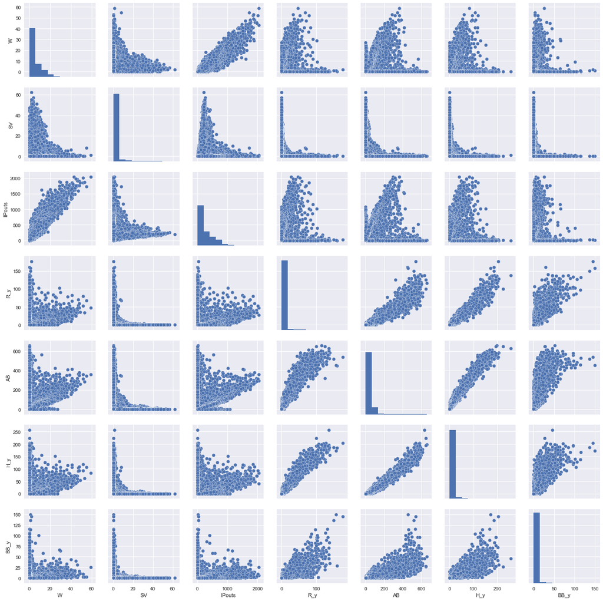

```python
# using the seaborn method to make scatter plots
# checking if the data is related
# the most clear linear relationship with wins is IPouts a Pitching variable, followed by AB in Batting and Hits.
# RBI though dropped earlier due to missing values also has a linear relation as shown by the correlation method

df=nodupmasterpitbat_df[['W','SV','IPouts','R_y','AB','H_y','BB_y']]
sns.pairplot(df)
plt.show()
```